# Exploratory Analysis of Weather Events with High Mortality and Economic Impact

```r
        "blowing snow extreme wind chi", "blowing snow/extreme wind chil",
        "cold and snow", "drifting snow", "early snow",
        "extreme wind chill/blowing sno", "first snow", "freezing drizzle",
        "freezing drizzle and freezing", "freezing rain", "freezing spray",
        "glaze", "glaze ice", "heavy rain/snow", "heavy snow rain",
        "high wind/snow", "ice", "ice jam", "ice on road", "ice pellets",
        "ice roads", "ice/strong wind", "icy roads", "late snow",
        "light freezing rain", "light snow", "light snow/flurries",
        "moderate snow", "mountain snows", "patchy ice", "prolong cold/snow",
        "rain/snow", "seasonal snow", "snow", "snow advisory", "snow and cold",
        "snow and wind", "snow high wind wind chill", "snow rain",
        "snow squall", "snow squalls", "snow/ bitter cold",
        "snow/blowing snow", "snow/cold", "snow/high wind", "snow/rain",
        "snowstorm", "wet snow"
    ),
    evtype := "winter weather"
];

valid.evtype = c(
    "Astronomical Low Tide", "Avalanche", "Blizzard",
    "Coastal Flood", "Cold/Wind Chill", "Debris Flow",
    "Dense Fog", "Dense Smoke", "Drought",
    "Dust Devil", "Dust Storm", "Excessive Heat",
    "Extreme Cold/Wind Chill", "Flash Flood", "Flood",
    "Frost/Freeze", "Funnel Cloud", "Freezing Fog",
    "Hail", "Heat", "Heavy Rain",
    "Heavy Snow", "High Surf", "High Wind",
    "Hurricane/Typhoon", "Ice Storm", "Lake-Effect Snow",
    "Lakeshore Flood", "Lightning", "Marine Hail",
    "Marine High Wind", "Marine Strong Wind", "Marine Thunderstorm Wind",
    "Rip Current", "Seiche", "Sleet",
    "Storm Surge/Tide", "Strong Wind", "Thunderstorm Wind",
    "Tornado", "Tropical Depression", "Tropical Storm",
    "Tsunami", "Volcanic Ash", "Waterspout",
    "Wildfire", "Winter Storm", "Winter Weather"
);

weather.table = weather.table[ evtype %in% tolower(valid.evtype), ];
weather.table$evtype = factor( weather.table$evtype );

#   This is from the ?tolower help information:
proper = function(ss)
{
    cap =
        function(st) paste(
            toupper( substring( st, 1, 1 ) ),
            tolower( substring( st, 2 ) ),
            sep = "",
            collapse = " "
        );

    sapply(
        strsplit( ss, split = " " ),
        cap,
        USE.NAMES = !is.null( names( ss ) )
    );
}

#   Capitalization for nice summarization later.
levels( weather.table$evtype ) =
    proper( levels( weather.table$evtype ) );
```

Now we check for `NA` values. Generally, `NA` values will prevent an observation from contributing to the analysis. `NA` values in `propdmgexp` and `cropdmgexp` are valid only if the accompanying `propdmg` and `cropdmg` are 0. We remove any observations that do not conform.

```r
weather.table = weather.table[
    !is.na(bgn_date) &
    !is.na(evtype) &
    !is.na(fatalities) &
    !is.na(injuries) &
    !is.na(propdmg) &
    !is.na(cropdmg) &
    !(is.na(propdmgexp) & propdmg != 0) &
    !(is.na(cropdmgexp) & cropdmg != 0),
];
```

Since `propdmg` and `propdmgexp` do not actually represent different variables, but rather a single variable spread across two columns, we combine them back into a single numerical value of the proper magnitude and store that back in `propdmg`, dropping `propdmgexp` from the data set. We do the same for `cropdmg` and `cropdmgexp`. Finally, since we are only interested in overall economic impact, we combine `cropdmg` and `propdmg` into a single new variable, `totaldmg`, and drop `cropdmg` and `propdmg` from the data set.

```r
weather.table[
    !is.na(propdmgexp),
    propdmg :=
        ifelse(
            propdmgexp == 'K',
            propdmg * 1000,
            ifelse(
                propdmgexp == 'M',
                propdmg * 1000000,
                propdmg * 1000000000
            )
        )
];
weather.table[ , propdmgexp := NULL ];

weather.table[
    !is.na(cropdmgexp),
    cropdmg :=
        ifelse(
            cropdmgexp == 'K',
            cropdmg * 1000,
            ifelse(
                cropdmgexp == 'M',
                cropdmg * 1000000,
                cropdmg * 1000000000
            )
        )
];

weather.table[ , cropdmgexp := NULL ];

weather.table[ , totaldmg := propdmg + cropdmg ];
weather.table[ , cropdmg := NULL ];
weather.table[ , propdmg := NULL ];

str( weather.table );
```

```
## Classes 'data.table' and 'data.frame':   900917 obs. of  5 variables:
##  $ bgn_date  : Date, format: "1950-04-18" "1950-04-18" ...
##  $ evtype    : Factor w/ 48 levels "Astronomical Low Tide",..: 40 40 40 40 40 40 40 40 40 40 ...
##  $ fatalities: num  0 0 0 0 0 0 0 0 1 0 ...
##  $ injuries  : num  15 0 2 2 2 6 1 0 14 0 ...
##  $ totaldmg  : num  25000 2500 25000 2500 2500 2500 2500 2500 25000 25000 ...
##  - attr(*, ".internal.selfref")=<externalptr>
```

```r
if ( !dir.exists( tidydata.dir ) )
{
    dir.create( tidydata.dir, recursive = TRUE );
}
saveRDS( weather.table, tidyfile );
```

## Results

The present impact of weather events on the economy and individual health depends largely on the fatilities, injuries, and damage done by those events. From the data provided by the NOAA, we can study this information to get an idea of which events are most damaging. However, due to advances in technology (such as the advent of early warning systems), changes in culture (such as education), changes in the environment (such as global warming), and changes in data collection techniques, not all data provided by NOAA will be relevant to a measure of the current impact of weather events.

The following figure shows total yearly fatalities, injuries, and property damage for each weather event. While specific details about individual weather events cannot be determined from this graph, it is clear that there is significant variation in the collected data over time.

```r
library(lubridate);
```

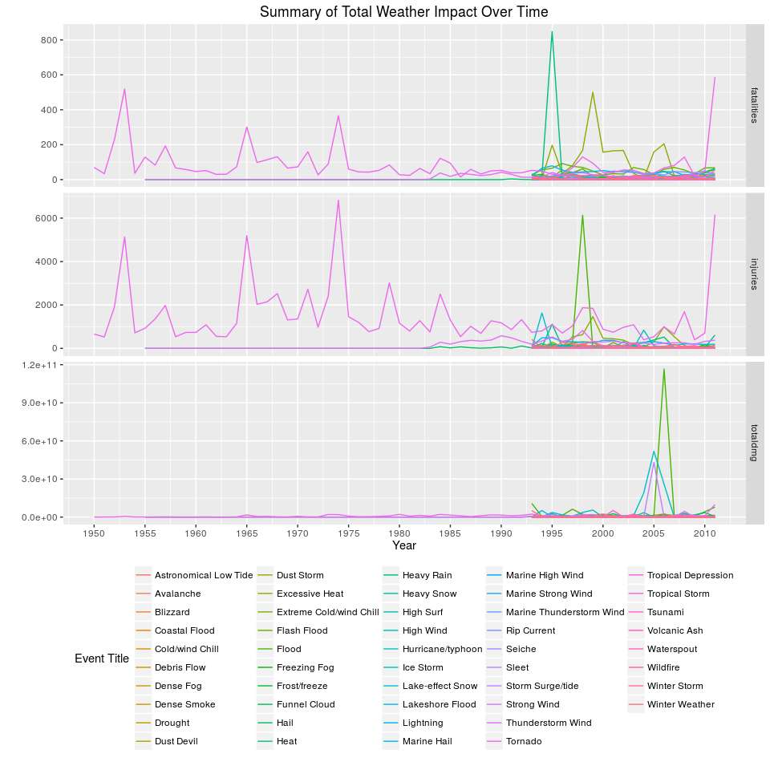

```r
library(ggplot2);
weather.impact.by.year =
    weather.table[ , year := year(bgn_date) ];

weather.impact.by.year =
    weather.impact.by.year[ ,
        list(
            fatalities = sum(fatalities),
            injuries = sum(injuries),
            totaldmg = sum(totaldmg)
        ),
        by="year,evtype"
    ];

weather.impact.by.year =
    melt(
         weather.impact.by.year,
         c( "year", "evtype" ),
         variable.name = "impact"
    );

wiby =
    ggplot( weather.impact.by.year, aes( year, value ) ) +
    geom_line( aes( col = evtype ) ) +
    facet_grid( impact ~ ., scales = "free_y" ) +
    theme( legend.position = "bottom" ) +
    xlab( "Year" ) +
    ylab( "" ) +
    ggtitle( "Summary of Total Weather Impact Over Time" ) +
    scale_x_continuous(
        breaks =
            round(
                seq(
                    min(weather.impact.by.year$year),
                    max(weather.impact.by.year$year),
                    by = 5
                ),
                0
            )
    ) +
    scale_color_discrete( name = "Event Title" );

print(wiby);
```

The plot shows that data collected earlier than 1993 is, at best, incomplete. In addition, the drop in fatalities for the data that does exist prior to 1993 signals changes in at least one of the elements mentioned earlier. Also, from the data processing step, we know there were significant problems with data collected prior to 1996.

[figure not shown]

```r
weather.impact =
    weather.table[ , year := year(bgn_date) ];

weather.impact =
    weather.impact[
        year >= 1996,
        list(
            injuries = mean(injuries),
            fatalities = mean(fatalities),
            totaldmg = mean(totaldmg)
        ),
        by = "evtype"
    ];

weather.impact =
    melt(
         weather.impact,
         c( "evtype", "totaldmg" ),
         variable.name = "health"
    );

healthplot =
    ggplot( weather.impact, aes( x = evtype, y = value, fill = health ) ) +
    geom_bar( stat = "identity", position = position_dodge() ) +
    theme(
        axis.text.x = element_text( angle = -60, hjust = 0 )
    ) +
    scale_y_continuous( expand = c(0, 0), limits = c(0, 6.8) ) +
    ggtitle(
        "Average Health Impact of Weather Effects Per Year (after 1996)"
    ) +
    xlab( "Weather Event Type" ) +
    ylab( "Number of People" ) +
    scale_fill_discrete( name = "" );

print( healthplot );
```

[figure not shown]

```r
econplot =
    ggplot( weather.impact, aes( x = evtype, y = totaldmg, fill = evtype ) ) +
    geom_bar( stat = "identity", show.legend = FALSE ) +
    theme(
        axis.text.x = element_text( angle = -60, hjust = 0 )
    ) +
    scale_y_continuous( expand = c(0, 0) ) +
    ggtitle(
        "Average Economic Impact of Weather Effects Per Year (after 1996)"
    ) +
    xlab( "Weather Event Type" ) +
    ylab( "Damage (in dollars)" ) +
    scale_fill_discrete( name = "" );

print( econplot );
```

Future investigation should probably work to resolve issues with the NOAA data set in a way that is robust. In addition, focus should be given to examining the impact of hurricanes, heat, storm surge (which is related to hurricanes), and tsunamis.